# Week 2 Milestone Report

Data Science Capstone

Shelby Bachman

February 2, 2020

# Setup

```r
rm(list = ls())
library(rprojroot)
library(R.utils)
library(dplyr)
library(stringr)
library(kableExtra)
library(tm)
library(quanteda)
library(ggplot2)
library(ggpubr)

path <- function(x) find_root_file(x, criterion = has_file('data-science-capstone.Rproj'))
```

# Download and load data

```r
# define filenames
file_twitter <- path('data/data_raw/en_US/en_US.twitter.txt')
file_news <- path('data/data_raw/en_US/en_US.news.txt')
file_blogs <- path('data/data_raw/en_US/en_US.blogs.txt')

# load files
filecon <- file(file_twitter, 'r')
text_twitter <- readLines(filecon, encoding = 'UTF-8', warn = FALSE)
close(filecon)

filecon <- file(file_news, 'r')
text_news <- readLines(filecon, encoding = 'UTF-8', warn = FALSE)
close(filecon)

filecon <- file(file_blogs, 'r')
text_blogs <- readLines(filecon, encoding = 'UTF-8', warn = FALSE)
close(filecon)
```

# Summary statistics

Below I report some information on each of the data files, as well as a summary of the strings contained in each file.

```r
summary_files <- data.frame(filename_full = c(file_twitter, file_news, file_blogs))
summary_files <- summary_files %>%
  rowwise() %>%
  mutate(filename = stringr::str_split(filename_full, '/')[[1]][10]) %>%
  select(-filename_full)

# get size of each file in Mb
file_sizes <- sapply(list(file_twitter, file_news, file_blogs), function(x) {(file.info(x)$size)/10^6} )

# get number of lines in each file
file_nLines <- sapply(list(text_twitter, text_news, text_blogs), function(x) {length(x)} )

# get minimum and maximum number of characters in a single line in each file
file_minChars <- sapply(list(text_twitter, text_news, text_blogs), function(x) {min(nchar(x))})
file_maxChars <- sapply(list(text_twitter, text_news, text_blogs), function(x) {max(nchar(x))})

# combine into a summary dataframe
data.frame(summary_files, file_sizes, file_nLines, file_minChars, file_maxChars) %>%
  kable(col.names = c('Filename', 'File size (Mb)', 'Number of lines',
                      'Min chars per line', 'Max chars per line')) %>%
  kable_styling(full_width = FALSE)
```

| Filename | File size (Mb) | Number of lines | Min chars per line | Max chars per line |
| --- | --- | --- | --- | --- |
| en_US.twitter.txt | 167.1053 | 2360148 | 2 | 140 |
| en_US.news.txt | 205.8119 | 1010242 | 1 | 11384 |
| en_US.blogs.txt | 210.1600 | 899288 | 1 | 40833 |

```r
# randomly sample the 18th line in each file
file_sample <- sapply(list(text_twitter, text_news, text_blogs), function(x) {x[18]})

# combine into a summary dataframe
data.frame(summary_files, file_sample) %>%
  kable(col.names = c('Filename', 'Sample data')) %>%
  kable_styling(full_width = FALSE)
```

| Filename | Sample data |
| --- | --- |
| en_US.twitter.txt | Packing for a quick move down the street… If only I had some movers… |
| en_US.news.txt | Born on April 15, 1925 in Pozzuoli, Naples, Italy she resided in North Plainfield since her marriage in 1945. |
| en_US.blogs.txt | We attend our friend Kendra’s wedding – such a joy to watch people see an end to year’s of waiting. |

# Subset data

Because the files are so large, I will subset the data and work with these subsets to develop my prediction algorithm. But first, since I want to utilize data from all three sources (twitter, news, and blogs), I combine the data from each file into a single object (`text_all`). Then, I randomly choose lines from each file so as to create 30 subsets of the data.

```r
# join data from all files into a single object
text_all <- c(text_twitter, text_news, text_blogs)

# set number of lines for each subsample by rounding down
nSamples <-  30 # total number of samples
nLinesPerSample <- floor(nLines_total / nSamples)

# randomly permute order of lines in text_all
text_all <- text_all[sample(nLines_total)]

for (ii in 1:nSamples) {

  # set indices of lines to read
  index_start <- nLinesPerSample*(ii-1) + 1
  index_end <- nLinesPerSample*ii
  indices <- index_start:index_end

  # subset lines and save
  text_subset <- text_all[indices]

  # write subset to file
  filename_subset <- paste(path('data/data_subset/subset_'), ii, '.txt', sep = '')
  filecon <- file(filename_subset, 'w')
  writeLines(text_subset, filecon)
  close(filecon)
  rm(filename_subset, text_subset)

}

rm(text_all, text_twitter, text_news, text_blogs)
```

# Functions to clean and tokenize

# Cleaning of data

Next, I will convert each subset of the data into a corpus and perform necessary cleaning on the data before further processing. Below I include a function `clean_text_data` which cleans a corpus using the `tm` package. My approach is based on my reading of [this tutorial](https://eight2late.wordpress.com/2015/05/27/a-gentle-introduction-to-text-mining-using-r/). The steps performed by the function are:

- Converting all characters in the corpus to lowercase
- Removing numbers from the corpus
- Replacing these punctuation marks within the corpus with spaces: /, @, #
- Removing all other punctuation marks from the corpus
- Stripping extra whitespace from the corpus
- As noted below, English stopwords are not removed in this step but in a subsequent step

```r
# this function cleans text data in a corpus
clean_text_data <- function(this_corpus) {

  # 1. change all text to lowercase
  this_corpus_cleaned <- tm_map(this_corpus, content_transformer(tolower))

  # 2. remove numbers from corpus
  this_corpus_cleaned <- tm_map(this_corpus_cleaned, removeNumbers)

  # 3. replace some punctuation with spaces, including :, -, /, \, |
  # use the tm package to create a "content_transformer" function
  # this function takes a function as input, which specifies what transformation is done
  # in this particular case, gsub is used to detect punctuation of interest & replace with a space
  convert_to_space <- content_transformer(function(x, pattern) {return (gsub(pattern, ' ', x))})
  this_corpus_cleaned <- tm_map(this_corpus_cleaned, convert_to_space, '/')
  this_corpus_cleaned <- tm_map(this_corpus_cleaned, convert_to_space, '@')
  this_corpus_cleaned <- tm_map(this_corpus_cleaned, convert_to_space, '#')

  # 4. remove punctuation
  this_corpus_cleaned <- tm_map(this_corpus_cleaned, removePunctuation)

  # 5. strip extra whitespace
  this_corpus_cleaned <- tm_map(this_corpus_cleaned, stripWhitespace)

  # not removing english stopwords until dfm creation, see below

  return(this_corpus_cleaned)

}
```

# Tokenization of data

After the data in each corpus is cleaned, I will *tokenize* each corpus, meaning I will divide each up into tokens. Below I define a function `tokenize_text_data` which tokenizes a corpus using the `quanteda` package. My approach is based on my reading of [this tutorial](https://tutorials.quanteda.io).

```r
tokenize_text_data <- function(this_corpus_cleaned) {

  # convert tm corpus to quanteda corpus
  this_corpus_cleaned_q <- corpus(this_corpus_cleaned)

  # segment corpus into tokens by word boundaries
  this_corpus_tokens <- tokens(this_corpus_cleaned_q,
                               remove_punct = TRUE,
                               remove_symbols = TRUE,
                               remove_twitter = TRUE,
                               remove_url = TRUE)

  return(this_corpus_tokens)

}
```

# Applying functions to clean and tokenize data

Having defined these functions, I now apply them to each subset of the data iteratively. On each iteration of the loop below, I read in one of the subsetted data files, I convert the loaded data to a corpus, I clean the corpus using the above-defined function (which relies on the `tm` package), I tokenize the corpus using the above-defined function (which relies on the `quanteda` package), and I write the tokenized data to a file. The result is that 30 tokenized data files, 1 for each subsetted data file, gets saved.

```r
###### loop through subsetted data and iteratively load and clean each file
# after the cleaning and tokenization steps, save the file
textFiles <- 1:30

for (ii in 1:length(textFiles)) {

  filename_toRead <- paste(path('data/data_subset/subset_'), textFiles[ii], '.txt', sep = '')
  filename_full <- str_split(filename_toRead, '/')[[1]][9]
  filename_prefix <- str_split(filename_full, '.txt')[[1]][1]

  # A. load the text file as a corpus
  this_corpus <- Corpus(DirSource(path('data/data_subset'), pattern = filename_full))

  # B. clean the corpus using tm
  this_corpus_cleaned <- clean_text_data(this_corpus)

  rm(this_corpus)

  # C. tokenize the corpus using quanteda
  this_corpus_tokens <- tokenize_text_data(this_corpus_cleaned)

  # write the tokenized data to file
  filename_tokenized <- paste(path('data/data_tokenized/'), filename_prefix, '_tokenized.RData', sep = '')
  save(this_corpus_tokens, file = filename_tokenized)

}

rm(this_corpus_cleaned, this_corpus_tokens)
```

# Create document feature matrices

Next, I load five subsets of the data (in subsequent weeks I may load more than one subset depending on memory demands), and join them together. This corresponds to approximately **1/6** of the original data being used in the testing here.

I then use the `quanteda` package to create document feature matrices and subsequently report dataframes with the frequency of each identified unigram, bigram, and trigram. In addition, I add columns in the bigram table to report the “starting” and “ending” word within each token, and in the trigram table, I report the two “starting words” and the single “ending” word within each token. The resulting dataframes will be used for my prediction algorithm. I save them so that they can be simply loaded as part of the shiny app implementation, rather than doing any of the preprocessing in the app.

```r
# load data files and join into single corpus
subsets_to_choose <- 5
for (ii in 1:subsets_to_choose) {
  filename_toRead <- paste(path('data/data_tokenized/subset_'), ii, '_tokenized.RData', sep = '')
  load(filename_toRead)

    if (ii == 1) {
    all_tokens <- this_corpus_tokens
  } else {
    all_tokens <- c(all_tokens, this_corpus_tokens)
  }

}

# create document feature matrices
this_dfm_unigram <- dfm(all_tokens, ngrams = 1)
this_dfm_bigram <- dfm(all_tokens, ngrams = 2)
this_dfm_trigram <- dfm(all_tokens, ngrams = 3)

rm(all_tokens, this_corpus_tokens)

# compute frequency of each feature in each matrix
this_freq_unigram <- textstat_frequency(this_dfm_unigram) %>%
  select(feature, frequency)
this_freq_bigram <- textstat_frequency(this_dfm_bigram) %>%
  select(feature, frequency)
this_freq_trigram <- textstat_frequency(this_dfm_trigram) %>%
  select(feature, frequency)

rm(this_dfm_unigram, this_dfm_bigram, this_dfm_trigram)

# create additional columns in bigram table
this_freq_bigram <- this_freq_bigram %>%
  rowwise() %>%
  mutate(start = str_split(feature, '_')[[1]][1],
         end = str_split(feature, '_')[[1]][2])

# create additional columns in trigram table
this_freq_trigram <- this_freq_trigram %>%
  rowwise() %>%
  mutate(first = str_split(feature, '_')[[1]][1],
         second = str_split(feature, '_')[[1]][2],
         start = paste(first, second, sep = ' '),
         end = str_split(feature, '_')[[1]][3]) %>%
  select(feature, frequency, start, end)

# save frequency tables
save(this_freq_unigram, file = path('data/data_dfm/freq_unigram.RData'))
save(this_freq_bigram, file = path('data/data_dfm/freq_bigram.RData'))
save(this_freq_trigram, file = path('data/data_dfm/freq_trigram.RData'))
```

# Token frequencies

A preview of each type of frequency table (e.g. for unigrams, bigrams, and trigrams) is shown below. Each table has been arranged such that the tokens are presented in decreasing order of frequency.

```r
kable(head(this_freq_unigram, 5)) %>%
  kable_styling(full_width = F)
```

| feature | frequency |
| --- | --- |
| the | 794160 |
| to | 459115 |
| and | 400398 |
| a | 397878 |
| of | 334085 |

```r
kable(head(this_freq_bigram, 5)) %>%
  kable_styling(full_width = F)
```

| feature | frequency | start | end |
| --- | --- | --- | --- |
| of_the | 72085 | of | the |
| in_the | 68699 | in | the |
| to_the | 35848 | to | the |
| for_the | 33204 | for | the |
| on_the | 33170 | on | the |

```r
kable(head(this_freq_trigram, 5)) %>%
  kable_styling(full_width = F)
```

| feature | frequency | start | end |
| --- | --- | --- | --- |
| one_of_the | 5684 | one of | the |
| a_lot_of | 5033 | a lot | of |
| thanks_for_the | 3904 | thanks for | the |
| to_be_a | 2967 | to be | a |
| going_to_be | 2884 | going to | be |

A histogram showing the frequency of the 30 most frequent unigrams, in alphabetical order, is shown below:

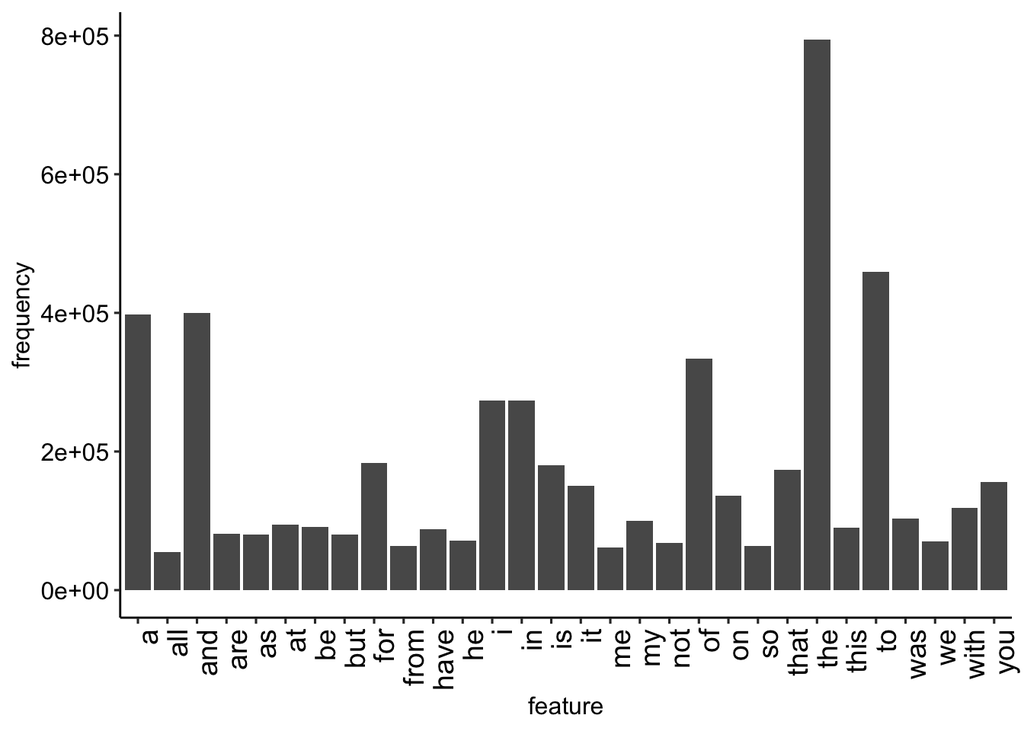

```r
ggplot(data = this_freq_unigram[1:30,],
       aes(x = feature, y = frequency)) +
  geom_bar(stat = "identity", position = "dodge") +
  theme_pubr() +
  theme(axis.text.x = element_text(size=14, angle=90, hjust=1, vjust=1))
```

A histogram showing the frequency of the 30 most frequent bigrams, in alphabetical order, is shown below:

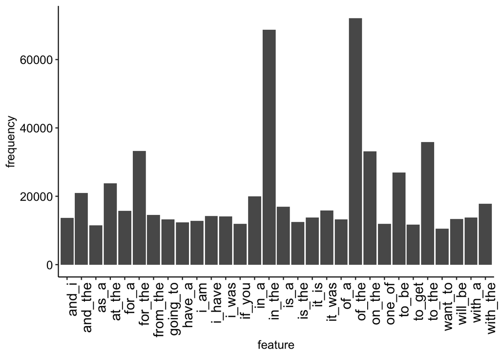

```r
ggplot(data = this_freq_bigram[1:30,],
       aes(x = feature, y = frequency)) +
  geom_bar(stat = "identity", position = "dodge") +
  theme_pubr() +
  theme(axis.text.x = element_text(size=14, angle=90, hjust=1, vjust=1))
```

A histogram showing the frequency of the 30 most frequent trigrams, in alphabetical order, is shown below:

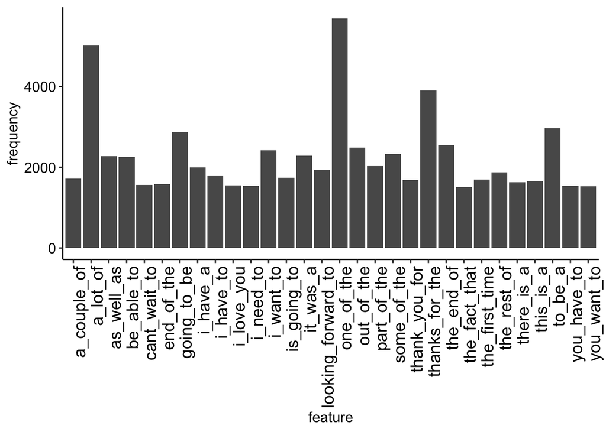

```r
ggplot(data = this_freq_trigram[1:30,],
       aes(x = feature, y = frequency)) +
  geom_bar(stat = "identity", position = "dodge") +
  theme_pubr() +
  theme(axis.text.x = element_text(size=14, angle=90, hjust=1, vjust=1))
```

# Plans for prediction algorithm and shiny app

The frequency data I calculated and visualized in the last steps will serve as the basis of my prediction method. My general approach will be to use these data to calculate observed and unobserved token probabilities for a given input word or set of words, and use those probabilities in tandem to compute the word most likely to follow the input(s).

Implementing the prediction algorithm in a Shiny app will be straightforward. I will load the feature frequency dataframes that will contain token frequencies reflecting between 1/10 and 1/6 of the originally provided data, avoiding the problem of having to preprocess the data within the app itself. I will ensure that the dataframes that will be loaded are not so large so as to slow down the token probability calculations.